# MA22019 - Spatial Data Analysis (Part 1)

19 March 2025

## Plan for Today

We start the final chapter on spatial data analysis:

- Types of spatial data
- Visualization of point-referenced data (Section 4.1)
- Problem Class 5
- Inverse Distance Weighting (Section 4.2)
- Comments on Coursework 1

## Motivation

In many applications we have spatial information:

- Air pollution modelling
- Disease outbreaks
- Ecological studies
- Socioeconomic studies
- Weather data

**How can we use this information in a data analysis?**

## Types of Spatial Data I

In spatial data analysis we consider **three** types of spatial data:

**Point-referenced data**

- Data are observed across a number of fixed sites
- Meteorology and mining are text book examples for this type of data

## Types of Spatial Data II

**Point-pattern data**

- Spatial locations are random variables
- Often found when analyzing disease outbreaks and in ecological studies

**Lattice / Areal unit data**

- Our sites are fixed areas (countries, counties, etc.)
- Examples include insurance claims and **image data**

## Visualizing point-referenced data

## Motivation

Let’s look at some temperature data for Germany

**-> R Markdown file**

Just using ggplot2 does not really provide a useful plot.

**Would a map provide additional information?**

## Shapefiles

One option is to add the boundaries of Germany.

Such data is available via the website [gadm.org](https://gadm.org/).

Let’s see how we can add such shapefile data to our plot

**-> R Markdown file**

## Projections

We used latitude and longitude within a Cartesian coordinate system.

**However**, the earth is not flat!

Converting locations on earth to a two-dimensional representation is called a **projection**.

We can choose a projection using the **coord_sf()** function.

**-> R Markdown file**

## Example

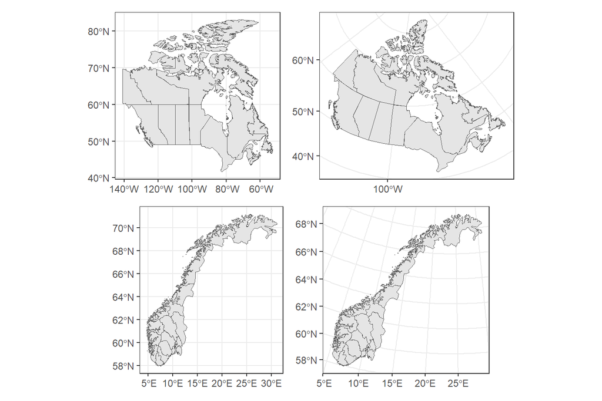

## Remarks about projections

- **WGS84 coordinate reference system** is the standard for GPS systems and Google Earth and has **st_crs(4326)**
- The projection may have a influence on how the plot is perceived
- Some projections are better for some parts of the world than for others
- For small areas we usually don’t need to consider projections.
- When using projections, we also need to project the points

**-> R Markdown file**

## Creating maps with ggspatial

It may be better to place points on a (colourful) map.

This will be achieved by importing OpenStreetMap data using the package **ggspatial()**

```r
library(ggspatial)
library(prettymapr)
```

**How to make it work**

1. Add the function “annotation_map_tile()”
2. Replace **geom_point()** by **geom_spatial_point()**

**-> R Markdown file**

## Problem Class 5

## Exercise

Please go to Moodle and download the materials for Problem Class 5.

## Inverse Distance Weighting

## Motivation

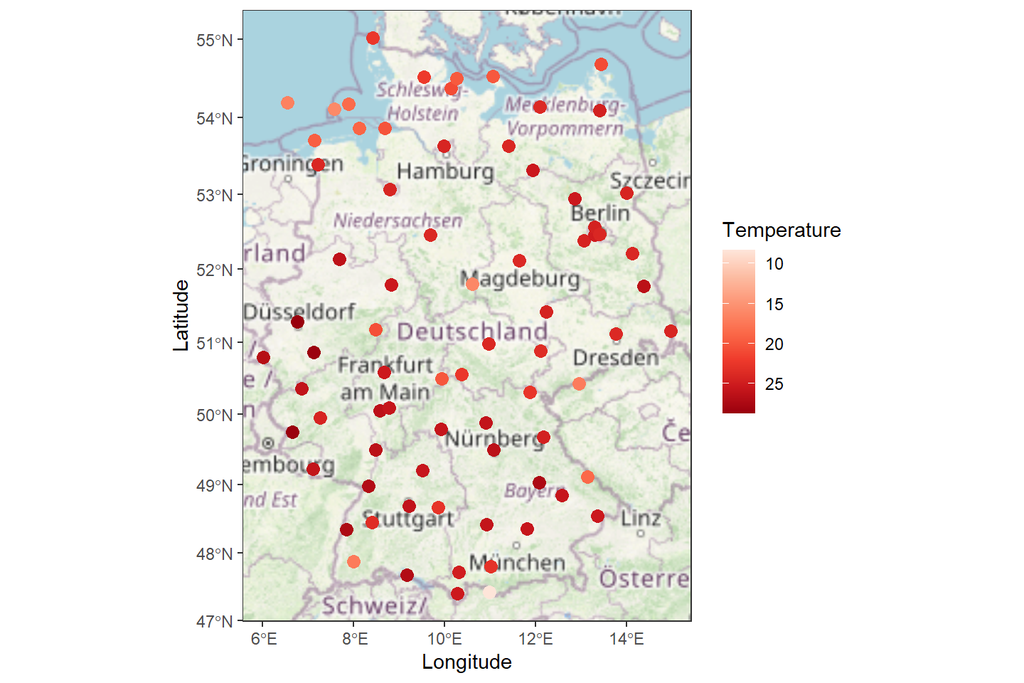

What is the temperature at an unobserved location?

## Notation

We introduce some notation to define our approach mathematically:

- \(n\) observations \(x_1,\ldots,x_n\in\mathbb{R}\)
- locations \(\mathbf{s}_1,\ldots,\mathbf{s}_n\in\mathbb{R}^2\)
- \(\mathbf{s}^*\) is the unobserved location for which we want to derive a prediction \(x^*\)

**How could we use the data and location information to get a prediction?**

## Inverse Distance Weighting

Let \(d: \mathbb{R}^2 \times \mathbb{R}^2 \to \mathbb{R}_+\) be a distance metric, such as \[ d(\mathbf{s}_1, \mathbf{s}_2) = ||\mathbf{s}_1-\mathbf{s}_2||_2= \sqrt{(s_{11}-s_{21})^2 + (s_{12}-s_{22})^2}. \]

Inverse distance weighting defines \[ x^* = \begin{cases} \dfrac{\sum_{i=1}^n w(\mathbf{s}_i,\mathbf{s}^*) x_i}{\sum_{i=1}^n, w(\mathbf{s}_i,\mathbf{s}^*)} & \mbox{if}~d(\mathbf{s}^*, \mathbf{s}_i)>0,\\ x_i & \mathrm{if}~d(\mathbf{s}^*, \mathbf{s}_i)=0, \end{cases} \] where \(w(\mathbf{s}_i,\mathbf{s}^*) = \left[d(\mathbf{s}_i,\mathbf{s}^*)\right]^{-p}\) and \(p>0\) is called the **power parameter**.

## Effect of the power parameter

We have to select a suitable value for \(p\).

**Example:** Suppose \(\mathbf{s}^* = (13.1, 51.0)\) for the German temperature data.

Let’s compare \(p=0.5\), \(p=2\) and \(p=20\).

**-> R Markdown file**

It may be useful to create a map of predicted values to:

- Study spatial pattern of the values
- Select a suitable value for \(p\)

## Remarks

- We only need a reasonable \(p\), it does not have to optimal
- The Euclidian distance for \(d(\mathbf{s}_1,\mathbf{s}_2)\) is not necessarily the best choice
  - **Example:** We ignored the aspect of altitude in our calculations
- Be careful when making predictions for locations that are not close to at least one location in \(\{\mathbf{s}_1, \ldots,\mathbf{s}_n\}\)

## Summary

Today we learned that

- Spatial data occurs in several applications
- There are **three** types of spatial data
- We can use shapefiles and maps to visualize the data
- When studying large areas, we have to consider the projection
- Inverse distance weighting may be used for predicting values at unobserved locations

## Coursework 1

## Summary

**Average: 58.7%**

**Office Hour for questions on the coursework:**

- Thursday (tomorrow): 12:30-15:00
- Monday: 9:00-10:15 and 16:00-18:00

**Advice for Coursework 2:**

- Don’t suppress the R code for loading packages
- Make use of R Markdown options to modify the size of plots.
- Clearly describe your approach.

## Reminder - What does it mean to be a data scientist

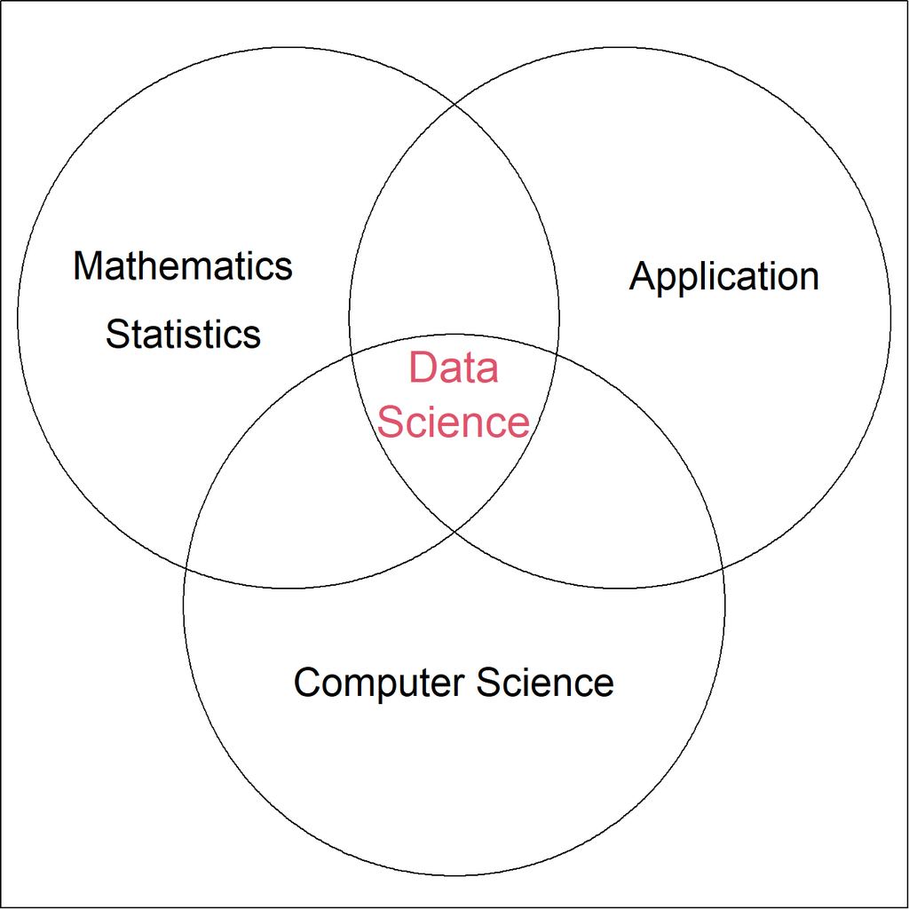